# Customer Segmentation Analysis (RFM + Clustering)

Javier Kangditya

# Introduction

## Project Overview

This project analyzes customer transaction behavior and segments customers using the RFM (Recency, Frequency, Monetary) framework combined with clustering techniques.

The objective is to uncover meaningful customer groups to support data-driven marketing and retention strategies.

Unlike predictive modeling tasks, this project focuses on unsupervised learning to identify natural patterns in customer behavior.

## Dataset Description

The dataset contains retail transaction records with the following variables:

- InvoiceNo
- StockCode
- Description
- Quantity
- InvoiceDate
- UnitPrice
- CustomerID
- Country

This dataset represents real-world transactional behavior suitable for customer segmentation analysis.

## Project Goals

- Clean and prepare transactional data
- Construct RFM features per customer
- Perform exploratory data analysis (EDA)
- Apply clustering to segment customers
- Interpret customer segments from a business perspective

# 1. Data Cleaning

```r
# Load necessary libraries
library(tidyverse)
library(lubridate)

# Load dataset
data <- read.csv("Data/Raw/data.csv")

# Preview dataset
glimpse(data)
```

```
## Rows: 541,909
## Columns: 8
## $ InvoiceNo   <chr> "536365", "536365", "536365", "536365", "536365", "536365"…
## $ StockCode   <chr> "85123A", "71053", "84406B", "84029G", "84029E", "22752", …
## $ Description <chr> "WHITE HANGING HEART T-LIGHT HOLDER", "WHITE METAL LANTERN…
## $ Quantity    <int> 6, 6, 8, 6, 6, 2, 6, 6, 6, 32, 6, 6, 8, 6, 6, 3, 2, 3, 3, …
## $ InvoiceDate <chr> "12/1/2010 8:26", "12/1/2010 8:26", "12/1/2010 8:26", "12/…
## $ UnitPrice   <dbl> 2.55, 3.39, 2.75, 3.39, 3.39, 7.65, 4.25, 1.85, 1.85, 1.69…
## $ CustomerID  <int> 17850, 17850, 17850, 17850, 17850, 17850, 17850, 17850, 17…
## $ Country     <chr> "United Kingdom", "United Kingdom", "United Kingdom", "Uni…
```

```r
head(data)
```

```
##   InvoiceNo StockCode                         Description Quantity
## 1    536365    85123A  WHITE HANGING HEART T-LIGHT HOLDER        6
## 2    536365     71053                 WHITE METAL LANTERN        6
## 3    536365    84406B      CREAM CUPID HEARTS COAT HANGER        8
## 4    536365    84029G KNITTED UNION FLAG HOT WATER BOTTLE        6
## 5    536365    84029E      RED WOOLLY HOTTIE WHITE HEART.        6
## 6    536365     22752        SET 7 BABUSHKA NESTING BOXES        2
##      InvoiceDate UnitPrice CustomerID        Country
## 1 12/1/2010 8:26      2.55      17850 United Kingdom
## 2 12/1/2010 8:26      3.39      17850 United Kingdom
## 3 12/1/2010 8:26      2.75      17850 United Kingdom
## 4 12/1/2010 8:26      3.39      17850 United Kingdom
## 5 12/1/2010 8:26      3.39      17850 United Kingdom
## 6 12/1/2010 8:26      7.65      17850 United Kingdom
```

```r
# Placeholder: handle missing values, duplicates, and correct data types

# Remove duplicates
data <- data %>% distinct()

# Drop rows with missing CustomerID
data <- data %>% drop_na(CustomerID)

# Remove cancelled / invalid transactions
data <- data %>%
  filter(Quantity > 0, UnitPrice > 0)

# Create TotalPrice feature
data <- data %>%
  mutate(TotalPrice = Quantity * UnitPrice)

# Convert InvoiceDate to datetime
data$InvoiceDate <- as.POSIXct(data$InvoiceDate, format = "%m/%d/%Y %H:%M")

# Check cleaned data
glimpse(data)
```

```
## Rows: 392,692
## Columns: 9
## $ InvoiceNo   <chr> "536365", "536365", "536365", "536365", "536365", "536365"…
## $ StockCode   <chr> "85123A", "71053", "84406B", "84029G", "84029E", "22752", …
## $ Description <chr> "WHITE HANGING HEART T-LIGHT HOLDER", "WHITE METAL LANTERN…
## $ Quantity    <int> 6, 6, 8, 6, 6, 2, 6, 6, 6, 32, 6, 6, 8, 6, 6, 3, 2, 3, 3, …
## $ InvoiceDate <dttm> 2010-12-01 08:26:00, 2010-12-01 08:26:00, 2010-12-01 08:2…
## $ UnitPrice   <dbl> 2.55, 3.39, 2.75, 3.39, 3.39, 7.65, 4.25, 1.85, 1.85, 1.69…
## $ CustomerID  <int> 17850, 17850, 17850, 17850, 17850, 17850, 17850, 17850, 17…
## $ Country     <chr> "United Kingdom", "United Kingdom", "United Kingdom", "Uni…
## $ TotalPrice  <dbl> 15.30, 20.34, 22.00, 20.34, 20.34, 15.30, 25.50, 11.10, 11…
```

```r
library(openxlsx)

# Save processed data
write.csv(data,
          "Data/Processed/retail_data_clean.csv",
          row.names = FALSE)
```

# 2. RFM Feature Engineering

```r
# Load library
library(dplyr)
library(lubridate)

# -----------------------------
# 1. Set snapshot date
# -----------------------------
snapshot_date <- max(data$InvoiceDate) + days(1)

# -----------------------------
# 2. Build RFM table
# -----------------------------
rfm <- data %>%
  group_by(CustomerID) %>%
  summarise(
    Recency = as.numeric(snapshot_date - max(InvoiceDate)),
    Frequency = n_distinct(InvoiceNo),
    Monetary = sum(TotalPrice)
  )

# -----------------------------
# 3. Inspect RFM result
# -----------------------------
glimpse(rfm)
```

```
## Rows: 4,338
## Columns: 4
## $ CustomerID <int> 12346, 12347, 12348, 12349, 12350, 12352, 12353, 12354, 123…
## $ Recency    <dbl> 326.117361, 2.873611, 75.984028, 19.124306, 310.867361, 36.…
## $ Frequency  <int> 1, 7, 4, 1, 1, 8, 1, 1, 1, 3, 1, 2, 4, 3, 1, 10, 2, 4, 2, 1…
## $ Monetary   <dbl> 77183.60, 4310.00, 1797.24, 1757.55, 334.40, 2506.04, 89.00…
```

```r
head(rfm)
```

```
## # A tibble: 6 × 4
##   CustomerID Recency Frequency Monetary
##        <int>   <dbl>     <int>    <dbl>
## 1      12346  326.           1   77184.
## 2      12347    2.87         7    4310
## 3      12348   76.0          4    1797.
## 4      12349   19.1          1    1758.
## 5      12350  311.           1     334.
## 6      12352   36.9          8    2506.
```

```r
# Check summary statistics
summary(rfm)
```

```
##    CustomerID       Recency         Frequency          Monetary
##  Min.   :12346   Min.   :  1.00   Min.   :  1.000   Min.   :     3.75
##  1st Qu.:13813   1st Qu.: 18.07   1st Qu.:  1.000   1st Qu.:   306.48
##  Median :15300   Median : 51.09   Median :  2.000   Median :   668.57
##  Mean   :15300   Mean   : 93.05   Mean   :  4.272   Mean   :  2048.69
##  3rd Qu.:16779   3rd Qu.:142.73   3rd Qu.:  5.000   3rd Qu.:  1660.60
##  Max.   :18287   Max.   :374.12   Max.   :209.000   Max.   :280206.02
```

```r
# Save RFM table
write.csv(rfm,
          "Data/Processed/rfm_table.csv",
          row.names = FALSE)
```

# 3. Exploratory Data Analysis (EDA)

```r
library(ggplot2)
library(dplyr)

# -----------------------------
# 1. Summary statistics
# -----------------------------
summary(rfm)
```

```
##    CustomerID       Recency         Frequency          Monetary
##  Min.   :12346   Min.   :  1.00   Min.   :  1.000   Min.   :     3.75
##  1st Qu.:13813   1st Qu.: 18.07   1st Qu.:  1.000   1st Qu.:   306.48
##  Median :15300   Median : 51.09   Median :  2.000   Median :   668.57
##  Mean   :15300   Mean   : 93.05   Mean   :  4.272   Mean   :  2048.69
##  3rd Qu.:16779   3rd Qu.:142.73   3rd Qu.:  5.000   3rd Qu.:  1660.60
##  Max.   :18287   Max.   :374.12   Max.   :209.000   Max.   :280206.02
```

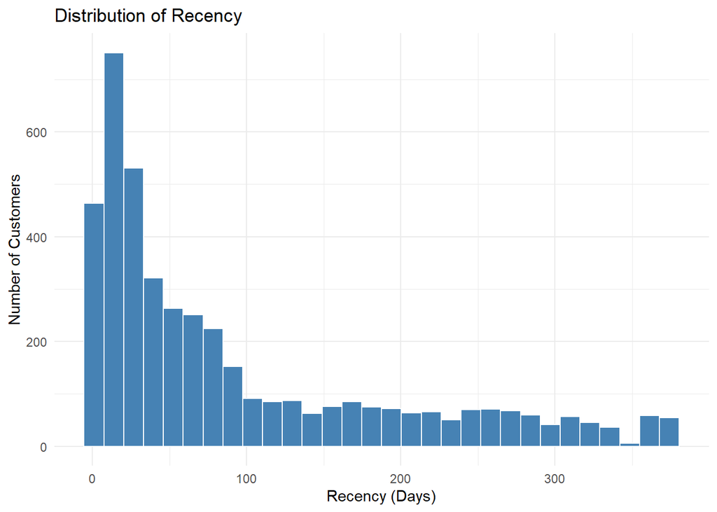

```r
# -----------------------------
# 2. Recency Distribution
# -----------------------------
p_recency <- ggplot(rfm, aes(x = Recency)) +
  geom_histogram(bins = 30, fill = "steelblue", color = "white") +
  theme_minimal() +
  labs(
    title = "Distribution of Recency",
    x = "Recency (Days)",
    y = "Number of Customers"
  )

p_recency
```

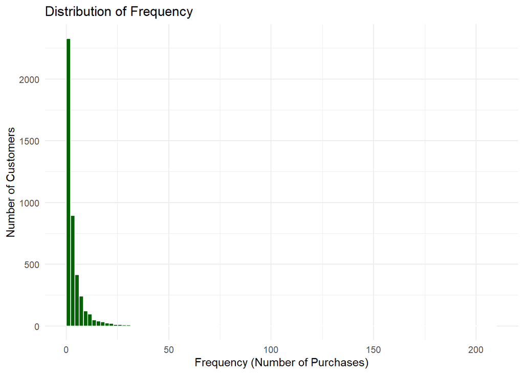

```r
ggsave("Outputs/Figures/recency_distribution.png",
       plot = p_recency,
       width = 6, height = 4, dpi = 300)

# -----------------------------
# 3. Frequency Distribution
# -----------------------------
p_frequency <- ggplot(rfm, aes(x = Frequency)) +
  geom_histogram(bins = 100, fill = "darkgreen", color = "white") +
  theme_minimal() +
  labs(
    title = "Distribution of Frequency",
    x = "Frequency (Number of Purchases)",
    y = "Number of Customers"
  )

p_frequency
```

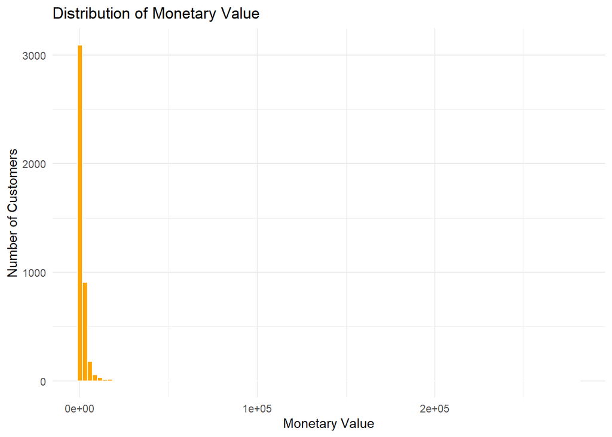

```r
ggsave("Outputs/Figures/frequency_distribution.png",
       plot = p_frequency,
       width = 6, height = 4, dpi = 300)

# -----------------------------
# 4. Monetary Distribution
# -----------------------------
p_monetary <- ggplot(rfm, aes(x = Monetary)) +
  geom_histogram(bins = 100, fill = "orange", color = "white") +
  theme_minimal() +
  labs(
    title = "Distribution of Monetary Value",
    x = "Monetary Value",
    y = "Number of Customers"
  )

p_monetary
```

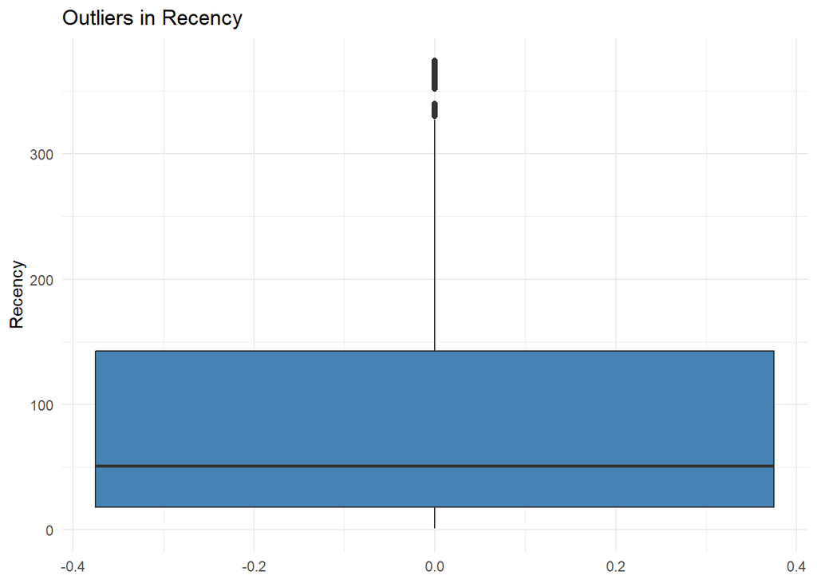

```r
ggsave("Outputs/Figures/monetary_distribution.png",
       plot = p_monetary,
       width = 6, height = 4, dpi = 300)

# -----------------------------
# 5. Boxplots
# -----------------------------
p_box_r <- ggplot(rfm, aes(y = Recency)) +
  geom_boxplot(fill = "steelblue") +
  theme_minimal() +
  labs(title = "Outliers in Recency")

p_box_r
```

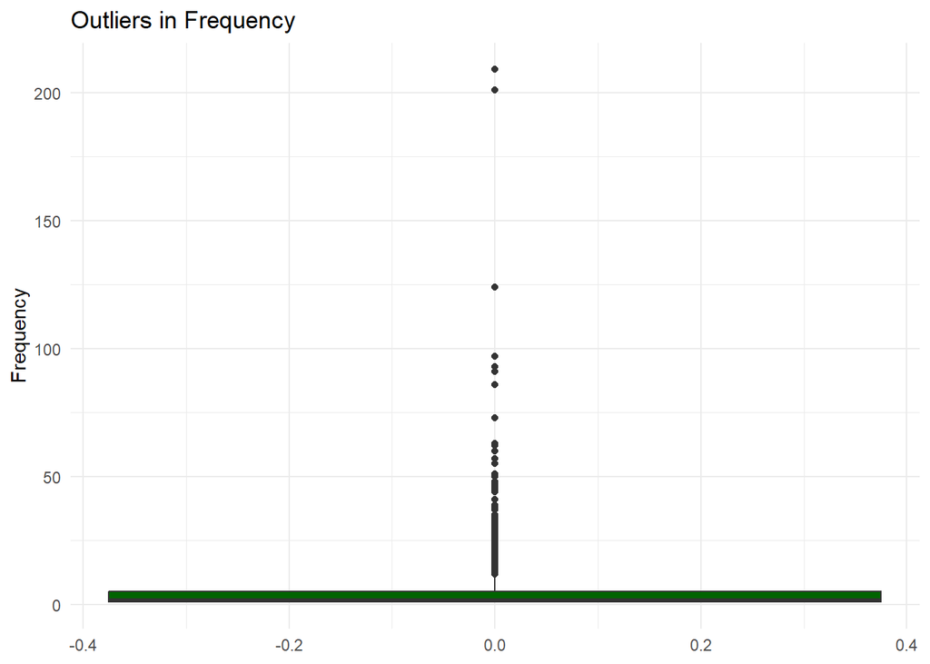

```r
ggsave("Outputs/Figures/recency_boxplot.png",
       plot = p_box_r,
       width = 6, height = 4, dpi = 300)

p_box_f <- ggplot(rfm, aes(y = Frequency)) +
  geom_boxplot(fill = "darkgreen") +
  theme_minimal() +
  labs(title = "Outliers in Frequency")

p_box_f
```

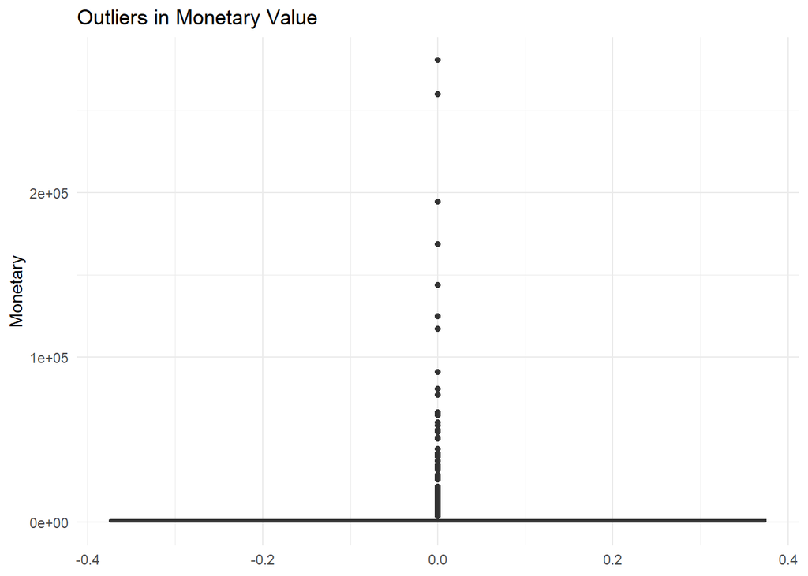

```r
ggsave("Outputs/Figures/frequency_boxplot.png",
       plot = p_box_f,
       width = 6, height = 4, dpi = 300)

p_box_m <- ggplot(rfm, aes(y = Monetary)) +
  geom_boxplot(fill = "orange") +
  theme_minimal() +
  labs(title = "Outliers in Monetary Value")

p_box_m
```

```r
ggsave("Outputs/Figures/monetary_boxplot.png",
       plot = p_box_m,
       width = 6, height = 4, dpi = 300)

# -----------------------------
# 6. Correlation
# -----------------------------
cor_matrix <- cor(rfm[, c("Recency", "Frequency", "Monetary")])
cor_matrix
```

```
##              Recency  Frequency   Monetary
## Recency    1.0000000 -0.2607686 -0.1219523
## Frequency -0.2607686  1.0000000  0.5527797
## Monetary  -0.1219523  0.5527797  1.0000000
```

# 4. Data Scaling for Clustering

```r
library(dplyr)

# Select RFM features only
rfm_features <- rfm %>%
  select(Recency, Frequency, Monetary)

# Standardize the data
rfm_scaled <- scale(rfm_features)

# Convert to data frame
rfm_scaled <- as.data.frame(rfm_scaled)

# Check result
summary(rfm_scaled)
```

```
##     Recency          Frequency           Monetary
##  Min.   :-0.9204   Min.   :-0.42505   Min.   :-0.22759
##  1st Qu.:-0.7497   1st Qu.:-0.42505   1st Qu.:-0.19390
##  Median :-0.4195   Median :-0.29514   Median :-0.15360
##  Mean   : 0.0000   Mean   : 0.00000   Mean   : 0.00000
##  3rd Qu.: 0.4967   3rd Qu.: 0.09457   3rd Qu.:-0.04319
##  Max.   : 2.8104   Max.   :26.59497   Max.   :30.95717
```

```r
write.csv(rfm_scaled,
          "Data/Processed/rfm_scaled.csv",
          row.names = FALSE)
```

# 5. Elbow Method

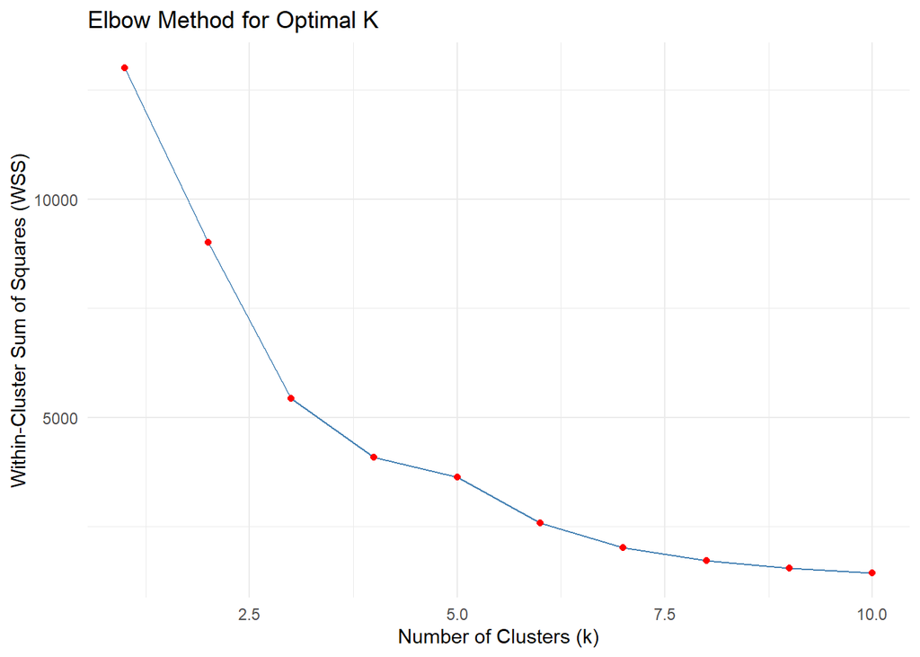

```r
set.seed(123)

wss <- vector()

# Try k from 1 to 10
for (k in 1:10) {
  kmeans_model <- kmeans(rfm_scaled, centers = k, nstart = 25)
  wss[k] <- kmeans_model$tot.withinss
}

# Convert to data frame
elbow_data <- data.frame(
  k = 1:10,
  wss = wss
)

# Plot Elbow Curve
library(ggplot2)

ggplot(elbow_data, aes(x = k, y = wss)) +
  geom_line(color = "steelblue") +
  geom_point(color = "red") +
  theme_minimal() +
  labs(
    title = "Elbow Method for Optimal K",
    x = "Number of Clusters (k)",
    y = "Within-Cluster Sum of Squares (WSS)"
  )
```

```r
# Save Elbow Method Plot
ggsave("Outputs/Figures/elbow_method.png",
       width = 6, height = 4, dpi = 300)
```

# 6. K-Means Clustering

```r
set.seed(123)

k_final <- 4

kmeans_model <- kmeans(rfm_scaled, centers = k_final, nstart = 25)

# Add cluster label to original RFM data
rfm$Cluster <- as.factor(kmeans_model$cluster)

# Check result
head(rfm)
```

```
## # A tibble: 6 × 5
##   CustomerID Recency Frequency Monetary Cluster
##        <int>   <dbl>     <int>    <dbl> <fct>
## 1      12346  326.           1   77184. 2
## 2      12347    2.87         7    4310  4
## 3      12348   76.0          4    1797. 4
## 4      12349   19.1          1    1758. 4
## 5      12350  311.           1     334. 1
## 6      12352   36.9          8    2506. 4
```

```r
# Save RFM with Cluster Labels
write.csv(rfm,
          "Data/Processed/rfm_with_clusters.csv",
          row.names = FALSE)
saveRDS(kmeans_model,
        "Outputs/Models/kmeans_model.rds")
```

# 7. Cluster Interpretation

```r
cluster_summary <- rfm %>%
  group_by(Cluster) %>%
  summarise(
    avg_recency = mean(Recency),
    avg_frequency = mean(Frequency),
    avg_monetary = mean(Monetary),
    count = n()
  ) %>%
  arrange(avg_recency)

cluster_summary
```

```
## # A tibble: 4 × 5
##   Cluster avg_recency avg_frequency avg_monetary count
##   <fct>         <dbl>         <dbl>        <dbl> <int>
## 1 3              7.66         82.5       127188.    13
## 2 2             16.0          22.1        12491.   209
## 3 4             44.5           3.66        1348.  3055
## 4 1            249.            1.55         476.  1061
```

```r
write.csv(cluster_summary,
          "Data/Processed/cluster_summary.csv",
          row.names = FALSE)
```

# 8. Cluster Visualization

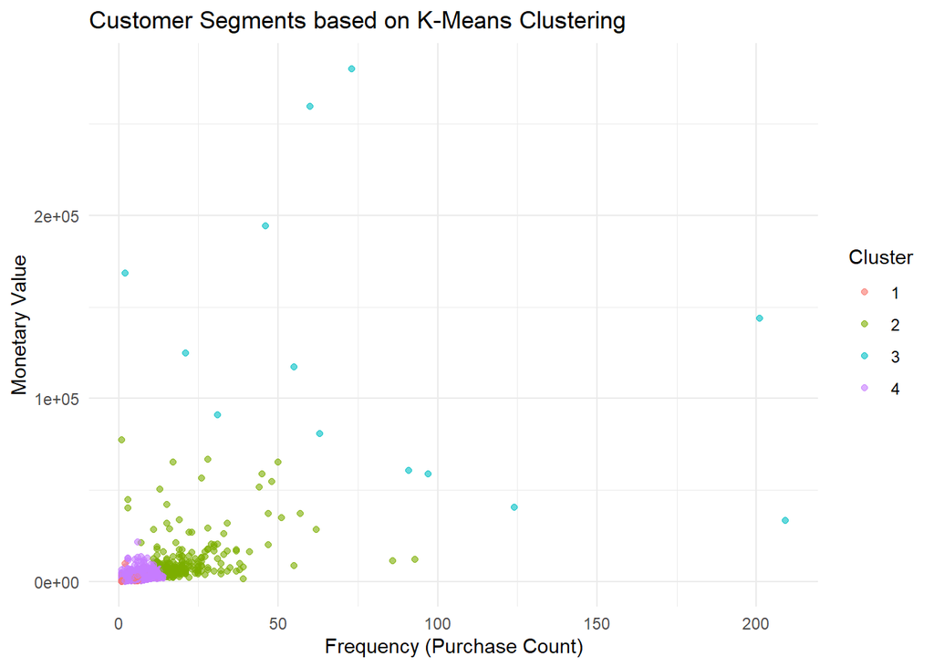

```r
library(ggplot2)

cluster_plot <- ggplot(rfm, aes(x = Frequency, y = Monetary, color = Cluster)) +
  geom_point(alpha = 0.6) +
  theme_minimal() +
  labs(
    title = "Customer Segments based on K-Means Clustering",
    x = "Frequency (Purchase Count)",
    y = "Monetary Value"
  )

cluster_plot
```

```r
ggsave("Outputs/Figures/kmeans_cluster_fm.png",
       plot = cluster_plot,
       width = 6, height = 4, dpi = 300)
```

# Conclusion & Insights

## 1. Summary of Findings

- **Exploratory Data Analysis (EDA):**
  - Customer behavior shows strong skewness in `Frequency` and `Monetary`, indicating that a small group of customers contributes most of the revenue.
  - `Recency` reveals that a significant portion of customers have not purchased recently, indicating potential churn risk.
  - Outliers exist in `Monetary`, representing high-value customers (VIP segment).
- **RFM Feature Engineering:**
  - RFM variables (`Recency`, `Frequency`, `Monetary`) were successfully constructed from transactional data.
  - These features provide a behavioral view of customers based on purchase timing, frequency, and spending value.
- **Clustering Results (K-Means):**
  - Customers were segmented into multiple clusters using K-Means clustering.
  - Each cluster shows different behavioral patterns in terms of recency, frequency, and monetary value.
  - A small group of customers represents **high-value VIP customers**, while the largest group consists of **low-value or occasional customers**.

## 3. Recommendations

- Focus retention strategies on **VIP customers** to maintain high revenue contribution.
- Implement **win-back campaigns** for inactive customers with high Recency values.
- Use targeted marketing campaigns to increase purchase frequency among occasional customers.
- Regularly update RFM segmentation to reflect changing customer behavior.
- Integrate this segmentation approach into CRM systems for data-driven marketing strategies.